# Mid Term Exam

Your Name

2/27/2019

For section 1 and 2 give short answers **one or to two sentences at most** for each question:

### Section 1 (20 points)

What is a p-value?

A pvalue is the proability of observing your data assuming the null hypothesis is true.

What is the differnce in a statistic and a parameter?

A statistic is our estimate based on a sample of population level parameter

Describe one of the causes of the reproducibility crisis.

Pressure to publish.

Why do we have to correct for multiple comparisons?

We would believe that our results were significant when it is actually just do to normal false positives that should occur at a rate of 5% of the time.

In Bayesian analyses what is a prior used for?

A prior allows us to incorporate additional knowledge into our estimate of the probability of the thing we are interested in.

### Section 2 (20 points)

What is the default null hypothesis of a two sample t-test?

That the mean of two groups is the same (drawn from the same population).

What is the null hypothesis of an ANOVA?

That the groups we are examining have the same mean.

You perform an experiment where chickens are fed corn, mixed seed, and a commercial diet. The chickens have final mean weights of 0.53, 0.69, and 0.41 kilograms respectively. You run an ANOVA on this data and get a p-value of 0.0012. What is your interpretation of this result?

That one or more of the diets leads to a different weight gain.

### Section 3 (20 points)

Report the probability of observing 18 or more retrogenes (offspring) on chromosome 1. Download the data (retrogene.csv) analyze it and write **two sentences** describing what you did, the result, and your inference.

```r
# write your code for this question here
dat <- read.csv("retrogenes.csv")
obs <- 18
result <- c()
for(i in 1:1000){
  result[i] <- sum(sample(dat$chromosome,
                      size=sum(dat$number.of.offspring.genes),
                      prob = dat$size,
                      replace=T) == 1)
}
emp.pval <- sum(result>=obs)/1000
emp.pval
```

```
## [1] 0.207
```

### Section 4 (20 points)

A researcher was intersted in whether differences in fishing practices in Canada and the US have an impact on the size of fish present on the shores of lake superior. Download the data (fish.csv) analyze it (using the simplest appropriate test) and write **two sentences** describing what you did, the result, and your inference.

```r
dat <- read.csv("fish.csv")
t.test(dat$US,dat$CAN)
```

```
##
##  Welch Two Sample t-test
##
## data:  dat$US and dat$CAN
## t = 2.1112, df = 169.81, p-value = 0.03622
## alternative hypothesis: true difference in means is not equal to 0
## 95 percent confidence interval:
##  0.07712819 2.29787181
## sample estimates:
## mean of x mean of y
##   21.1290   19.9415
```

I performed a two sample t-test (two-way). I found that there was only a 3.6% chance that we would observe a statistic as extreme as we observe in this dataset. For this reason I believe that fish in these two sample really do have a differnce in size.

### Section 5 (20 points)

Download the data file fins.csv and make a plot that does a good job of illustrating the difference in data from males and females. The plot should be publication quality.

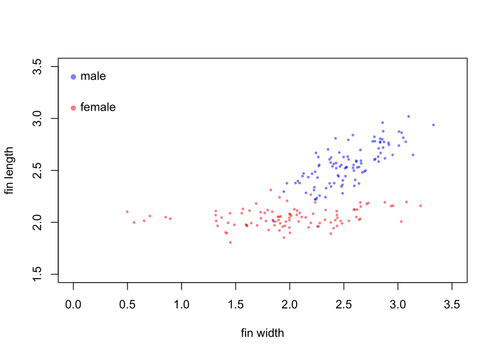

```r
dat <- read.csv("fins.csv")
plot(y=dat$fin_length[dat$sex=="male"],
     x=dat$fin_width[dat$sex=="male"],
     pch=16, col=rgb(0,0,1,.5),
     cex=.5,xlab="fin width",ylab="fin length",
     xlim=c(0,3.5),
     ylim=c(1.5,3.5))
points(y=dat$fin_length[dat$sex=="female"],
       x=dat$fin_width[dat$sex=="female"],
       pch=16,
       col=rgb(1,0,0,.5),cex=.5)
points(x=c(0,0),y=c(3.4,3.1),
       pch=16,col=c(rgb(0,0,1,.5),
                    rgb(1,0,0,.5)))
text(x=c(0,0),
     y=c(3.4,3.1),
     c("male","female"),pos=4)
```

### Extra Credit (20 points)

You develop a test based on expression profiles that can predict the developmental fate of two closely related neural progenitor cells as either motor or sensory (you know these are equally common in the pool of neural progenitor cells). The test has 99% probability of correctly predicting development of a motor neuron and a 50% probability of correctly predicting the development of a sensory neuron. What is the proability that a cell predicted by your test to develop into a motor neuron will actually develop as a motor neuron?

p(A|B) = P(A)P(B|A) / P(B) A = develop as motor neuron assuming test positive for that

```r
pb <- .99*.5 + .5*.5
pba <- .99
pa <- .5
pp <- (pa*pba)/pb
pp
```

```
## [1] 0.6644295
```

There is 66.4% probability that the cell will develop as a motor neuron.